# Version Prediction Analysis Report

Christoph Hartleb

2024-10-06

# Executive Summary

This report provides a comprehensive analysis of the distribution and progression of software version numbers, with a focus on the **major** and **minor** versions. Using a dataset containing historical version information, we conducted an in-depth analysis to uncover patterns and trends in the software release cycle.

Key aspects of the analysis include:

The report concludes that a data-driven approach to version prediction can significantly improve the planning and management of software development processes, enabling teams to anticipate future updates, optimize release schedules, and streamline project management.

# Introduction

In software development, version control plays a critical role in managing updates, feature releases, and bug fixes. Each version of a software product is typically identified by a version number, which often follows a structured format, such as `<major>.<minor>`. The major version generally indicates significant releases with potentially breaking changes, while the minor version reflects smaller updates or incremental improvements.

This report aims to analyze the distribution of **major** and **minor** software version numbers from a dataset of historical versions. By studying these versioning trends and patterns, we can gain valuable insights into the software release cycle, the rate of updates, and how changes are structured over time. Understanding these patterns can help development teams better predict future versioning, streamline their development cycles, and manage resources more effectively.

The report will cover several aspects, including:

- **Exploratory Data Analysis (EDA)**: A detailed exploration of the version numbers to uncover trends and distribution patterns.
- **Feature Engineering**: The transformation of raw version data into features that are useful for predictive modeling.
- **Modeling and Prediction**: Implementing machine learning models to predict future versions based on historical patterns.
- **Insights and Recommendations**: Key findings from the analysis that provide actionable insights for better version management.

By the end of this report, readers will have a deeper understanding of the software’s versioning structure and its evolutionary patterns, allowing for more strategic decisions in future version planning.

# Data Description and Understanding

This section aims to provide a thorough description of the dataset utilized in this analysis, detailing the initial exploration process and the inherent characteristics of the data.

**Data Source:**  
The data for this analysis was sourced from a CSV file located at `data/reprocessed/feature_engineered_versions.csv`. This file contains structured information regarding the major and minor versions of the software, which is crucial for understanding the versioning patterns over time.

**Data Types and Structure:**  
The dataset comprises a total of

```
## [1] 107
```

and

```
## [1] 3
```

The key features include:

- **major:** Integer values representing the major version numbers of the software.
- **minor:** Integer values representing the minor version numbers associated with each major version.

**Summary Statistics:**  
Initial exploration of the dataset revealed the following summary statistics:

- **Missing Values:** The dataset was found to be complete, with no missing values present across both columns.

Identified columns with missing values:

```
##              major              minor cumulative_version
##                  0                  0                  0
```

**Data Quality Issues and Addressed Solutions:**  
Throughout the exploration process, several data quality considerations were made:

- **Handling Missing Values:** Given that no missing values were identified, this aspect required no action.
- **Removing Duplicates:** The dataset was assessed for duplicate entries, ensuring the integrity of the data before analysis.

**Visualizations of Important Features:**  
To enhance understanding and communicate findings effectively, several visualizations were created. Key features, such as the distribution of major and minor versions, were represented through bar charts, illustrating the frequency of each version. These visualizations facilitate a clearer interpretation of the versioning patterns and trends present in the dataset.

# Exploratory Data Analysis (EAD)

## Data Structure

The first few rows of the dataset show that it consists of major and minor version numbers. It is evident that the data follows a structured pattern, where the major version remains constant for a series of entries, while the minor version increments regularly:

```
##   major minor cumulative_version
## 1     1     0                1.0
## 2     1     1                1.1
## 3     1     2                1.2
## 4     1     3                1.3
## 5     1     4                1.4
## 6     1     5                1.5
```

## Total amount of Data

```
## [1] 107
```

## Major and Minor Version Insidghts

[output not shown]

[output not shown]

## Version Distribution

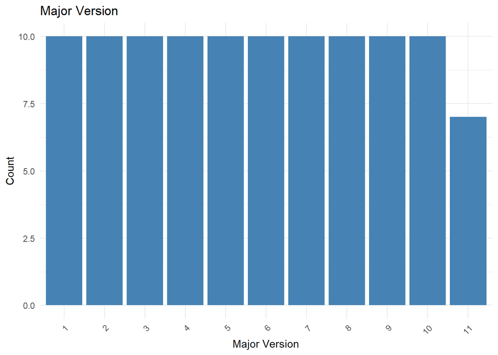

The distribution of major versions is notably uniform, indicating a relatively equal representation of available major versions across the dataset. However, it is worth noting that major version 11 appears significantly less frequently. Several factors may contribute to this discrepancy; it is possible that the versioning history for this particular release was limited, or that data related to it is incomplete. Further investigation is warranted to understand the underlying causes of this anomaly.

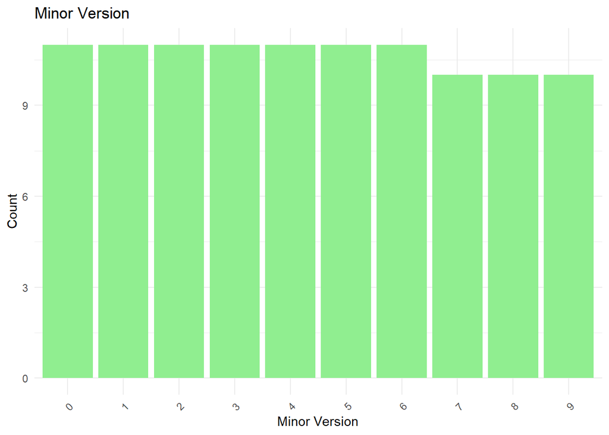

## Version Progression Over Time

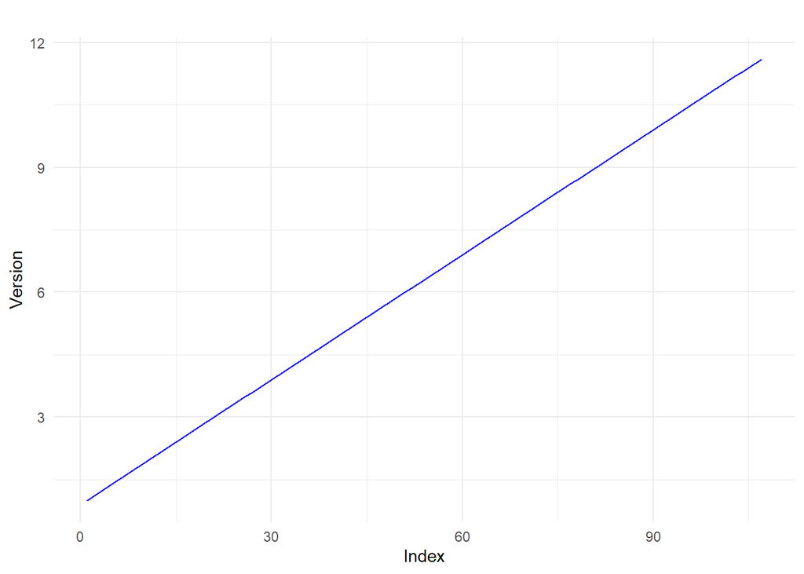

# Data Preprocessing and Engineering

## Feature Engineering

**Objective:** The aim of this section is to detail the process of creating and transforming features from the existing dataset to enhance the performance of the predictive models. The focus is on providing clear insights into how these features were derived and their relevance to the overall analysis.

**New Features Created from Existing Data:**  
The initial dataset comprised two key features: **major** and **minor** versions. To enrich the dataset for modeling purposes, the following was created:

**Version Number:** A new feature, **version_number**, was derived by combining the major and minor version numbers into a single numeric representation. This transformation was achieved using the formula:

version_number = major + ( minor / 10 )

This allows for a continuous representation of versioning, making it easier for models to interpret the relationship between major and minor updates.

**Justification for Feature Creation:**  
The creation of the **version_number** feature is justified as it encapsulates the relationship between major and minor versions in a single numeric format, facilitating more effective learning for regression models.

**Feature Scaling or Normalization:**  
Given that the **version_number** feature is a continuous variable, no explicit feature scaling was applied. However, normalization may be considered in future analyses if additional features with varying scales are introduced.

**Data Visualization:**  
To further illustrate the relationship between features and their impact on model performance, visualizations such as scatter plots and bar charts can be generated. These plots can help depict how major and minor versions contribute to the overall software versioning trend, aiding in understanding feature relationships and their significance.

## Data Quality Assessment

Before feature engineering, a comprehensive analysis was conducted to evaluate the integrity and quality of the dataset. The dataset was sourced from `data/raw/major_minor_versions.csv`, which contains the **major** and **minor** version numbers.

## Missing Values Analysis

```
## Number of missing values:  0
```

To ensure data reliability, we assessed for missing values: - **Total Missing Values:** Identified the total count of missing values in the dataset. - **Column-wise Missing Values:** Pinpointed which columns had missing data, allowing for focused remediation. - **Row Removal:** If any missing values were present, they were filtered out incomplete entries, ensuring only fully populated records were retained for analysis.

After validating data quality, we converted the **major** and **minor** version columns to integers, ensuring consistency and facilitating analysis.

# Modeling Selection and Evaluation

**Objective:** This section details the model selection, training, and evaluation process undertaken to derive insights from the dataset. It outlines the rationale for selecting specific models, describes the training and validation methodology, and provides an evaluation of model performance.

## Selection

**Model Selection:**  
For this analysis, a combination of models was evaluated to identify the most suitable approach for predicting cumulative software versions based on major and minor version inputs. The selected models include:

1. [**Linear Regression:**](https://cran.r-project.org/web/packages/tidypredict/vignettes/lm.html) A fundamental model that provides interpretability and a straightforward understanding of the relationship between features.
2. [**Random Forest:**](https://cran.r-project.org/web/packages/randomForest/index.html) An ensemble learning method well-suited for capturing complex non-linear relationships within the data.

**Rationale Behind Choosing the Models:**  
The selection of linear regression allows for clear interpretability of the impact of major and minor versions on the cumulative version. Conversely, the random forest model is selected for its robustness and ability to manage complex interactions and non-linear relationships, which are likely present in versioning data.

**Training, Validation, and Test Splits:**  
The dataset was split into training and testing sets, where 80% of the data was allocated for training the models and 20% for testing their performance. This division helps ensure that the model is adequately trained while allowing for an unbiased evaluation on unseen data.

**Cross-Validation Approach:**  
Although not explicitly implemented in this initial evaluation, a cross-validation strategy, such as k-fold cross-validation, could be employed in future iterations to further validate model performance and stability across different subsets of the data.

**Hyperparameter Tuning:**  
The random forest model’s performance may be optimized further through hyperparameter tuning techniques, such as grid search or random search. This would involve adjusting parameters like the number of trees, maximum depth, and minimum samples split to improve model accuracy.

**Algorithms Used and Rationale:**  
The random forest algorithm is particularly suitable for this task as it can capture non-linear relationships that linear regression may overlook. This choice is crucial given the potential complexities in versioning data, where simple linear assumptions might not hold.

**Challenges Encountered During Modeling:**  
One notable challenge was ensuring that the dataset was free from missing values before training the models. Functions were employed to check for missing values and remove incomplete rows, ensuring a robust dataset for model training.

## Evaluation

**Objective:** To evaluate the performance of the selected models and justify the final model selection based on quantitative metrics.

**Audience:** Technical and some non-technical stakeholders.

**Performance Metrics:**  
The models were evaluated using the Root Mean Square Error (RMSE) as the primary performance metric. This metric provides a clear measure of prediction accuracy by quantifying the average error between predicted and actual values.

**Visualizations:**  
To visually assess the effectiveness of the selected model, scatter plots comparing actual versus predicted cumulative versions were created. This allows for a straightforward evaluation of prediction accuracy and helps identify any patterns or discrepancies in model performance:

**Final Model Selection:**  
Based on the evaluation results, the best-performing model was identified:

```
## The best model is: linear with RMSE: 0.03501768
```

```
## [1] "linear"
```

Its details were saved for future reference. The final model selection process was guided by the objective of achieving the lowest RMSE, ensuring optimal predictive performance for the given task.

# Results and Insights

## Model Performance:

[output not shown]

## Insights on Version Progression:

### Visualizations:

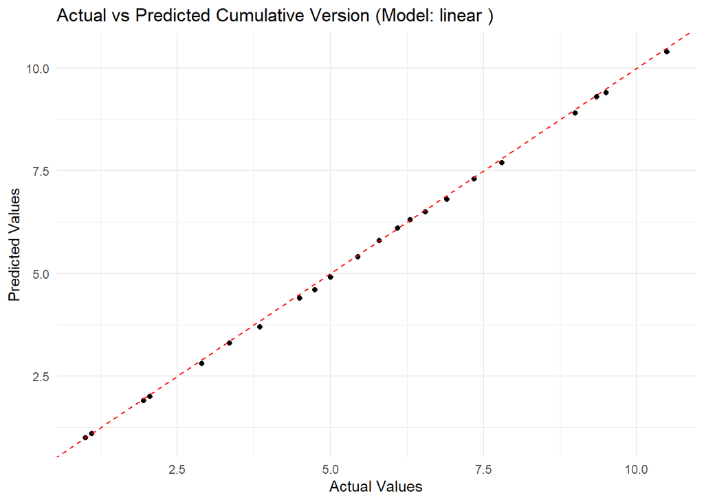

- **Actual vs. Predicted Values**: A plot of actual vs. predicted cumulative versions showed a near-perfect alignment between the two, indicating high predictive accuracy. The red dashed line representing perfect predictions closely followed the data points, further confirming the model’s precision.

```
##    1    2    3    4    5    6    7    8    9   10   11   12   13   14   15   16
##  1.0  1.1  1.9  2.0  2.8  3.3  3.7  4.4  4.6  4.9  5.4  5.8  6.1  6.3  6.5  6.8
##   17   18   19   20   21   22
##  7.3  7.7  8.9  9.3  9.4 10.4
```

- **Version Distribution**: Bar charts of major and minor version distributions provided a clear visualization of the release patterns, highlighting the consistency and volume of updates for each version.
- **Version Progression Trend**: A line plot of version progression over time displayed a smooth upward trend, reflecting consistent development and incremental updates to the software over time.

# Conclusion and Recommendation

## Summary of Key Insights:

### Recommendations for Business Decisions:

Based on the analysis, the following recommendations are suggested: 1. **Release Planning**: The model’s ability to predict version trends can be leveraged to forecast future software releases, helping with resource planning and roadmap development. 2. **Versioning Strategy**: The distribution analysis of major and minor version releases suggests that development may benefit from balancing the frequency of minor updates with larger, more impactful major releases. 3. **Development Cycles**: The predictive accuracy of the models suggests that future releases can be more effectively planned, with a focus on aligning product milestones and versioning patterns to market demands.

### Future Work:

To improve upon the current model and further refine predictions, the following steps are suggested: 1. **Additional Data Collection**: Incorporate more historical versioning data, especially from earlier releases, to improve model accuracy and better capture long-term trends. 2. **Feature Engineering**: Introduce new features that capture other aspects of versioning (e.g., patch versions, feature enhancements, bug fixes) to create a more granular prediction model. 3. **Model Improvements**: Explore advanced machine learning algorithms such as gradient boosting or neural networks to further enhance prediction accuracy, especially for more complex versioning patterns.

### Suggestions for Improving Model or Data Quality:

- **Data Quality**: Ensure that version data is consistently logged and includes all relevant version identifiers, such as patch numbers, to improve the granularity of predictions.
- **Model Monitoring**: Implement regular model retraining to ensure the predictions remain aligned with evolving versioning trends and new release strategies.
- **Feedback Loop**: Establish a feedback loop where prediction errors are regularly analyzed, and corrective actions are taken to continuously refine the model.